# Peer-graded Assignment: R Markdown and Leaflet

Randy Borregard

December 19, 2016

```r
library(leaflet)
my_map <- leaflet() %>%
addTiles()
my_map
```

[output not shown]

The Washington Monument is an obelisk on the National Mall in Washington, D.C., built to commemorate George Washington, once commander-in-chief of the Continental Army and the first American president. Located almost due east of the Reflecting Pool and the Lincoln Memorial, the monument, made of marble, granite, and bluestone gneiss,is both the world’s tallest stone structure and the world’s tallest obelisk, standing 554 feet 7 inches (169.046 m) tall according to the National Geodetic Survey (measured 2013-14) or 555 feet 5 inches (169.294 m) tall according to the National Park Service (measured 1884).In 1975, a ramp covered a step at the entrance to the monument, so the ground next to the ramp was raised to match its height, reducing the remaining height to the monument’s apex. The obelisk was originally intended by its designer to stand 600 feet (183 m) tall, but questions regarding the design of the foundations caused the height to be set lower by the time the building was eventually completed. It is the tallest monumental column in the world if all are measured above their pedestrian entrances, but two are taller when measured above ground, though they are neither all stone nor true obelisks.

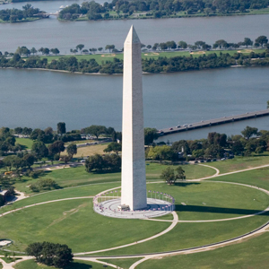

Washington Monument

```r
WashMont <- c("<a href= 'https://www.nps.gov/wamo/index.htm' >Washington Monument</a>")
leaflet() %>%
addTiles() %>%
addMarkers(lat=38.889500, lng=-77.035300, popup = WashMont)
```

[interactive chart not shown]

Click above on blue marker to continue to National Park Service website